# Word Cloud-Generator für die Veröffentlichungsdatenbanken bei IT.NRW

Lars Hofmann

2018-03-20

# Überblick

Das R-Paket [`wordcloud`](https://cran.r-project.org/web/packages/wordcloud/) von Ian Fellows ist ein einfaches und elegantes Tool für die randomisierte Erzeugung von Schlagwortwolken (engl.: tag cloud, word cloud). Damit lassen sich die häufigsten Wörter insbesondere bei umfangreichen Texten in einer zusammenfassenden grafischen Visualisierung darstellen.

Die SVG-Dateigröße von `svglite` schrumpft im Vergleich zur Standard-SVG-Schnittstelle von R auf ein Fünfundzwanzigstel (ca. 17 kb)!

Zusammen mit dem R-Paket [`svglite`](https://cran.r-project.org/web/packages/svglite/) können diese Schlagwortwolken als extrem kleine SVG-Dateien bereitgestellt werden. Die Texte bleiben erhalten (keine Pfadumwandlung) und können komplett nachbearbeitet werden.

Im Folgenden möchte ich für die von [`IT.NRW`](https://www.it.nrw.de) betriebenen Veröffentlichungsdatenbanken [`Landesdatenbank Nordrhein-Westfalen`](https://www.ldb.nrw.de) (LDB), [`Regionaldatenbank Deutschland`](https://www.regionalstatistik.de) (RDB) und [`Kommunale Bildungsdatenbank`](https://www.bildungsmonitoring.de) (BDB) Schlagwortwolken mit zentralen Begriffen des jeweiligen statistischen Datenangebots erzeugen. Da sich hier eine Gewichtung (= Textgröße in der Cloud) nach Häufigkeiten nicht eignet, werden diese Faktor manuell bestimmt. Die Farbgebung wird dem Corporate Design von [`IT.NRW`](https://www.it.nrw.de) angepasst.

# Setup und Eingangsdaten

**Setup**

Die Vorgehensweise ist abhängig vom Betriebssystem.

Zuerst kümmern wir uns um die benötigten R-Pakete. Das folgende Skript prüft, ob diese bereits auf dem System installiert sind. Fehlende Pakete werden direkt installiert und in die Session geladen. Gegebenenfalls müssen Pakete mit Administratorrechten installiert werden.

```r
libs <- c("wordcloud", "svglite")
for (x in libs){
  if(x %in% rownames(installed.packages()) == FALSE) {
    print(paste0("installing ", x, "..."))
    install.packages(x)
  }
  else{
    print (paste0(x, " is already installed"))
  }
  library(x, character.only = TRUE)
}
```

```
## [1] "wordcloud is already installed"
## [1] "svglite is already installed"
```

**Eingangsdaten**

Als Eingangsdaten benötigen wir:

- drei Dateien mit den jeweiligen Begriffen der Datenbanken “[DB]” sowie den Gewichtungen: `words_[DB].csv`
- drei Dateien mit den jeweiligen Farbpaletten für die Datenbanken “[DB]” (RGB-Absolutwerte): `cali_[DB].csv`

Für Komma-separierte Daten nutzen wir `read.csv`. Wegen der deutschen Umlaute muss das Argument `encoding` gesetzt werden.

```r
terms_ldb <- read.csv("words_ldb.csv",
                      header=TRUE,
                      colClasses=c("character",
                      rep("numeric",2)),
                      encoding = "latin1")
terms_rdb <- read.csv("words_rdb.csv",
                      header=TRUE,
                      colClasses=c("character",
                      rep("numeric",2)),
                      encoding = "latin1")
terms_bdb <- read.csv("words_bdb.csv",
                      header=TRUE,
                      colClasses=c("character",
                      rep("numeric",2)),
                      encoding = "latin1")

knitr::kable(
  head(terms_ldb), caption = "Ausschnitt aus der
  Begriffsdatei der LDB."
)
```

Ausschnitt aus der Begriffsdatei der LDB.

| word | mean | freq |
| --- | --- | --- |
| Landesdatenbank NRW | 0.0 | 6 |
| Bevölkerung | 5.0 | 5 |
| Wirtschaft | 5.0 | 5 |
| VPI | 5.0 | 5 |
| Beschäftigte | 4.4 | 5 |
| Arbeitslose | 4.1 | 4 |

Die Farbpaletten müssen zunächst in Data Frames `calib_[DB]` geladen werden

```r
calib_ldb <- read.csv("cali_ldb.csv", header = TRUE)
calib_rdb <- read.csv("cali_rdb.csv", header = TRUE)
calib_bdb <- read.csv("cali_bdb.csv", header = TRUE)

knitr::kable(
  head(calib_ldb), caption = "RGB-Werte für die
  Farbgebung der LDB."
)
```

RGB-Werte für die Farbgebung der LDB.

| name | r | g | b |
| --- | --- | --- | --- |
| Schwarz | 0 | 0 | 0 |
| Grau | 218 | 218 | 218 |
| Blutorange | 232 | 78 | 15 |
| Grasgruen | 177 | 200 | 11 |
| Sonnengelb | 242 | 149 | 5 |
| Hausblau | 0 | 100 | 156 |

# Erzeugen der Schlagwortwolken

Die Funktion `set.seed()` stellt die Reproduzierbarkeit des Ergebnisses sicher. Der von `wordcloud` genutzte R-Zufallszahlengenerator wird damit auf bestimmte Werte “fixiert”.

Die Skalierung der SVG-Abbildungen unterscheiden sich je nach dem, ob die Abbildungen in das RMarkdown-Dokument oder in separate Dateien exportiert werden. Mit `scale = c([MAX], [MIN])` lässt sich das Verhalten beeinflussen.

[figure not shown]

```r
#set.seed(1034)
set.seed(5231)
clrs_ldb <- rgb(calib_ldb$r, calib_ldb$g, calib_ldb$b,
                names = calib_ldb$name, max = 255)

#svglite("cloud_ldb2.svg")
wordcloud(words = terms_ldb$word,
          freq = terms_ldb$freq,
          min.freq = 1,
          random.order = FALSE,
          rot.per = 0.3,
          scale = c(2.5,.3),
          colors = clrs_ldb,
          system_fonts = list(sans = "DejaVu Sans"))
```

```r
#dev.off()
```

Für die zwei anderen Wolken passen wir die obere Größenklasse [MAX] in `scale` an, damit die DB-Bezeichnungen die Breite ausfüllen.

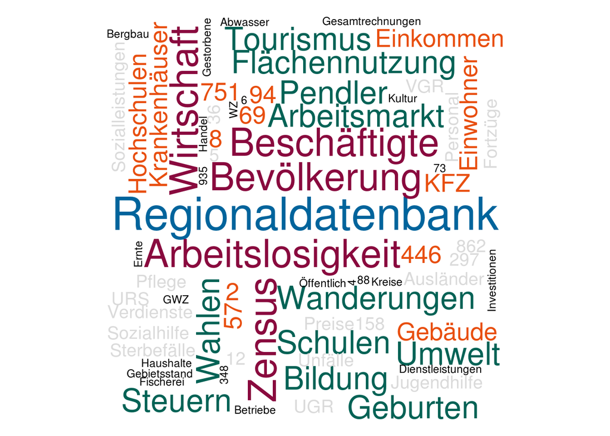

```r
#set.seed(1034)
set.seed(5231)
clrs_rdb <- rgb(calib_rdb$r, calib_rdb$g, calib_rdb$b,
                names = calib_rdb$name, max = 255)

#svglite("cloud_rdb2.svg")
wordcloud(words = terms_rdb$word,
          freq = terms_rdb$freq,
          min.freq = 1,
          random.order = FALSE,
          rot.per = 0.3,
          scale = c(3.1,.3),
          colors = clrs_rdb,
          system_fonts = list(sans = "DejaVu Sans"))
```

```r
#dev.off()
```

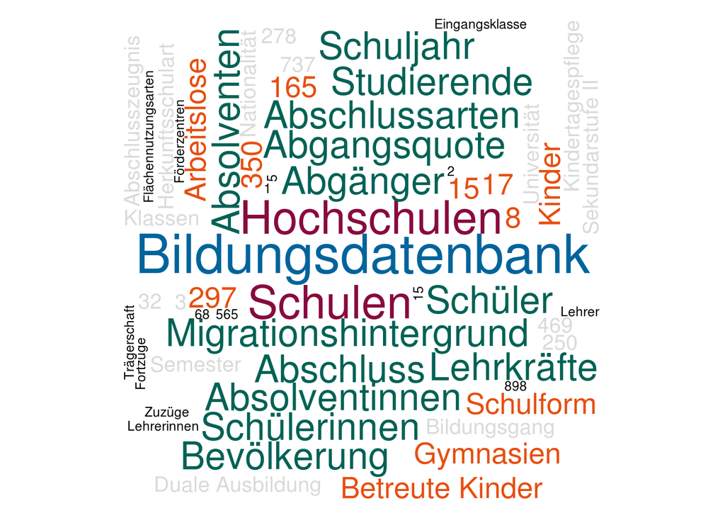

```r
#set.seed(1034)
set.seed(5281)
clrs_bdb <- rgb(calib_bdb$r, calib_bdb$g, calib_bdb$b,
                names = calib_bdb$name, max = 255)

#svglite("cloud_bdb2.svg")
wordcloud(words = terms_bdb$word,
          freq = terms_bdb$freq,
          min.freq = 1,
          random.order = FALSE,
          rot.per = 0.3,
          scale = c(3.1,.3),
          colors = clrs_bdb,
          system_fonts = list(sans = "DejaVu Sans"))
```

```r
#dev.off()
```

# Ergebnis

Wie schon eingangs erwähnt, können die mittels `svglite` auf Minimalgröße exportierten SVG-Dateien umfangreich nachbearbeitet werden. Àlle wichtigen SVG-Attribute wie `viewbox`, `font-size`, `fill`, `font-family` sowie die Begriffe selbst stehen als indizierbare Elemente zur Verfügung.